# Connecting Ratio Cuts to Kernel Methods

STAT-S 475/675

John Koo

Dec 2, 2019

# Inner Products and Kernel Methods

Inner product matrix $B = \tilde{X} \tilde{X}^\top$

Equivalent to $[b_{ij}] = x_i^\top x_j$

Can be thought of as some sort of “similarity” measure between $x_i$ and $x_j$

What if we try some other “inner products”?

# Inner Products and Kernel Methods

Some kernel functions we have seen so far …

- Linear kernel: $K(x_i, x_j) = x_i^\top x_j$
- Polynomial kernel: $K(x_i, x_j) = (x_i + x_j + c)^d$
- Heat kernel: $K(x_i, x_j) = \exp(-h ||x_i - x_j||^2)$
- Cosine similarity: $K(x_i, x_j) = \frac{x_i^\top x_j}{||x_i|| ||x_j||}$

# Inner Products and Kernel Methods

Let $x_i \in \mathbb{R}^q$ for $i = 1, ..., n$  
Let $K: \mathbb{R}^q \times \mathbb{R}^q \to \mathbb{R}$  
$\phi: \mathbb{R}^q \to \mathbb{R}^p$

$K(x_i, x_j)$ is a kernel function iff …

- there exists a representation function $\phi(x)$ such that $K(x_i, x_j) = \phi(x_i)^\top \phi(x_j)$
- i.e., $K(x_i, x_j)$ is an inner product of some transformation of $x_i$ and $x_j$

… iff …

- $K(x_i, x_j) = K(x_j, x_i)$
- $B \in \mathbb{R}^{n \times n}$ such that $[b_{ij}] = K(x_i, x_j)$ is symmetric and positive semidefinite
- i.e., we can fully decompose kernel matrix $B$

In more practical settings, we can relax these criteria

In the text, we centered $B$, i.e., $\tilde{B} = P B P$, before decomposing

# Inner Products and Kernel Methods

Why do we care?

- The linear kernel $K(x_i, x_j) = x_i^\top x_j$ is great for representing ellipsoidal data
- The representation function $\phi$ induced by kernel function $K$ can transform our data to something that’s more ellipsoidal

# Inner Products and Kernel Methods

Why do we care about ellpisoidal data?

- Many methods we use assume ellipsoidal (more specifically, Gaussian) data
  - LDA/QDA
  - Gaussian mixture models
  - K-means clustering
- Also works when we need nonlinear decision boundaries but want to use a classification model that assumes linear decision boundaries

# Kernel K-Means

From the text …

$$\begin{align}
H^* & = \arg\min_H \text{Tr}(B) - \text{Tr}(B H (H^\top H)^{-1} H^\top) \\
& = \arg\max_H \text{Tr}(N^{-1/2} H^\top B H N^{-1/2})
\end{align}$$

Where …

- $H \in \{0, 1\}^{n \times k}$ is a cluster assignment matrix
  - $h_{ij} = \begin{cases} 0 & x_i \not\in C_j \\ 1 & x_i \in C_j \end{cases}$
- $N = H^\top H \in \mathbb{N}^{k \times k}$ is a diagonal matrix where $n_{ij} = \begin{cases} |C_i| & i = j \\ 0 & \text{otherwise} \end{cases}$

We have methods for solving Euclidean $k$-means that have been demonstrated to work fairly well (exchange, Lloyd, stochastic gradient descent)

If $B$ is a valid kernel, there is a Euclidean representation for each $x_i$, $y_i = \phi(x_i)$, and then we can just use one of our methods on $Y$

# Ratio Cut

From the text …

$$H^* = \arg\min_H \text{Tr}(N^{-1/2} H^\top L H N^{-1/2})$$

Where …

- $L = T - W$ is the combinatorial graph Laplacian of an undirected graph $\mathcal{G}$ with similarity weights $W$
- $t_{ij} = \begin{cases} \sum_i w_{ij} & i = j \\ 0 & \text{else} \end{cases}$, i.e., $t_{ii}$ is the degree of vertex $v_i$
- $H$ and $N$ defined the same way as in kernel $k$-means

# Ratio Cut

Solving ratio cut for a given graph is NP-hard (proportional to number of vertices times number of clusters)

This is because it is a discrete optimization problem

We can relax our discrete constraints on $H$ and $N$

- Let $U = H N^{-1/2} = \begin{cases} u_{ij} = 0 & v_i \not\in C_j \\ u_{ij} = n_j^{-1/2} & v_i \in C_j \end{cases}$
- Then we can rewrite the optimization problem as $U^* = \arg\min_U \text{Tr}(U^\top L U)$
- Now let $U$ be any $n \times k$ matrix
- Then $\arg\min_U \text{Tr}(U^\top L U) = \begin{bmatrix} v_0 & \cdots & v_{k-1} \end{bmatrix}$, i.e., the first $k$ eigenvectors of $L$ in increasing order of eigenvalues
- This gives us a continuous matrix, so the heuristic is to use $k$-means clustering (using Lloyd’s method or otherwise) on the first $k$ eigenvectors of $L$
- This is called **spectral clustering**

# Connecting Ratio Cut and Kernel K-Means

Kernel $k$-means: $\arg\max_U \text{Tr}(U^\top B U)$

- In practice, can be solved by decomposing $B$ and using Lloyd’s method (or similar)

Ratio cut: $\arg\min_U \text{Tr}(U^\top L U)$

- In practice, can be solved by decomposing $L$ and using Lloyd’s method (or similar)

A few more leaps to connect the two …

- Since $L$ is positive semidefinite, so is $L^\dagger$, the generalized inverse of $L$
- $\implies L^\dagger$ is a kernel matrix!
- The continuous relaxation of ratio cut says to do a partial unscaled embedding, i.e., $\begin{bmatrix} v_0 & \cdots & v_{k-1} \end{bmatrix}$
- If instead we do a full scaled embedding $\begin{bmatrix} v_1 / \sqrt{\sigma_1} & \cdots & v_{n-1} / \sqrt{\sigma_{n-1}} \end{bmatrix}$ and solve $k$-means on this embedding, this is equivalent to solving kernel $k$-means with kernel matrix $L^\dagger$

**However**: $\arg\min_U \text{Tr}(U^\top L U) \neq \arg\max_U \text{Tr}(U^\top L^\dagger U)$

Ratio cut and kernel $k$-means are only connected through spectral clustering

# Example: Double Spiral

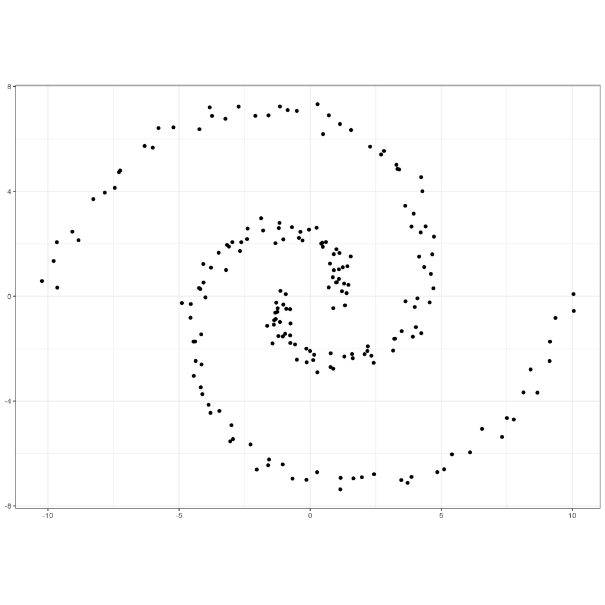

# Example: Double Spiral

- Construct an adjacency matrix $W$
- $k$-nearest neighbors method (setting $k =10$)

$$w_{ij} = \begin{cases}
1 & x_j \text{ is one of the 10 nearest neighbors of } x_i \\
0 & \text{otherwise}
\end{cases}$$

# Example: Double Spiral

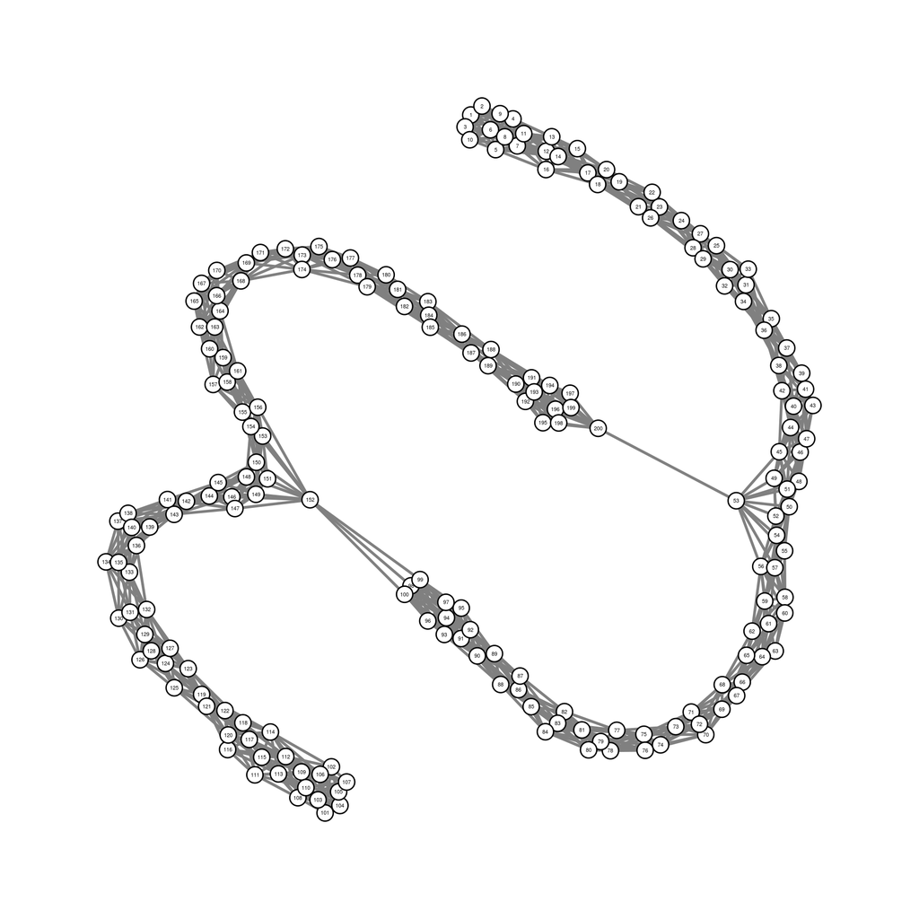

# Aside: Motivation for Spectral Clustering

Alternative to $k$-means clustering on Euclidean data

vs.

Partitioning a graph

# Aside: Motivation for Spectral Clustering

Alternative to $k$-means clustering

- Start with data in Euclidean space
- $k$-means clustering doesn’t work well for non-spherical clusters
- Use some sort of kernel method (e.g., heat kernel) to restructure into another Euclidean configuration
- Graph and similarity matrix construction is an intermediate step
  - Spectral clustering methods developed with this motivation require you to construct a very specific type of graph

Partitioning a graph

- Start with a graph
- No Euclidean configuration to begin with
- Ultimate goal is to partition the graph, not cluster points in $\mathbb{R}^d$
- Any sort of Euclidean configuration or embedding is an intermediate step

# Aside: Motivation for Spectral Clustering

Alternative to $k$-means clustering on Euclidean data

vs.

Partitioning a graph

# Aside: Motivation for Spectral Clustering

Alternative to $k$-means clustering on Euclidean data

vs.

**Partitioning a graph**

# Example: Double Spiral

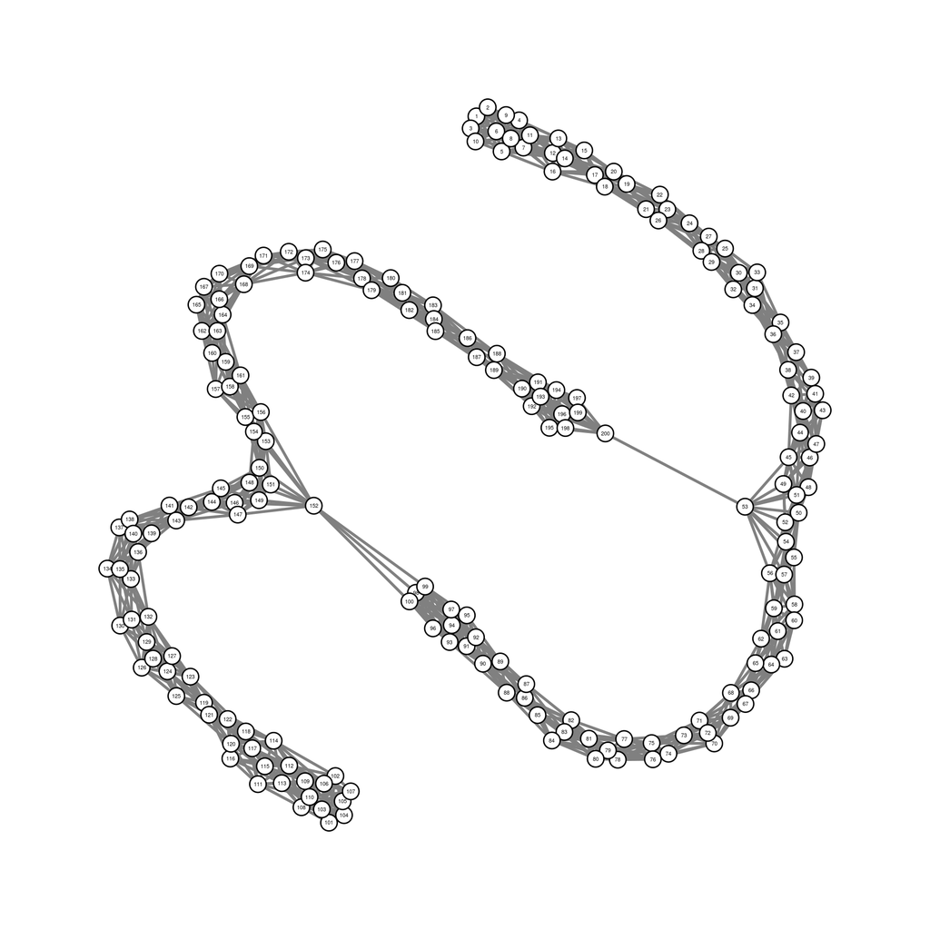

# Example: Double Spiral

- Set $k = 2$
- We have a qualitative *a priori* clustering in mind based on the picture of the graph (and also the spirals)
- Note that *our* idea of an ideal clustering may not agree with the ratio cut metric, $\text{Tr}(N^{-1/2} H^\top L H N^{-1/2})$
- Ratio cut metric provides an easy way to compare clusterings
- Ratio cut metric based on *a priori* clustering: 0.08

# Example: Double Spiral

$k = 2$

Embedding: $X_k = \begin{bmatrix} v_0 & v_1 \end{bmatrix}$

Since $v_0 = e / \sqrt{n}$, this is an embedding in $\mathbb{R}^1$

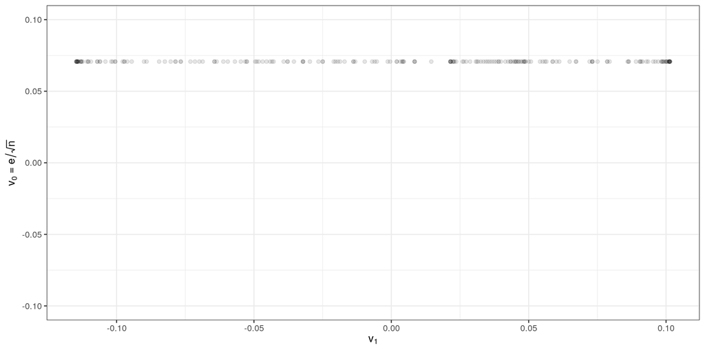

# Example: Double Spiral

Applying 2-means clustering on the embedding:

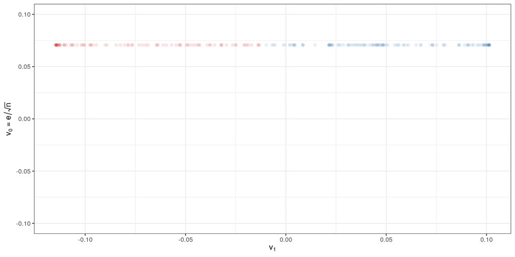

Ratio cut metric: 0.328 (worse than baseline 0.08)

# Example: Double Spiral

Applying 2-means clustering on the embedding:

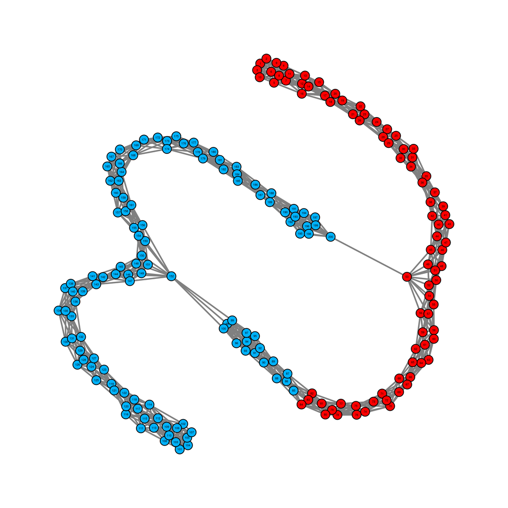

# Example: Double Spiral

Kernel $k$-means and (the continuous relaxation of) ratio cut are equivalent if we do a *full* embedding

In this case, we get equivalent solutions if we have at least 3 embedding dimensions

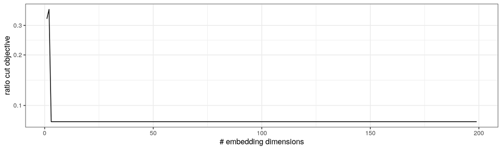

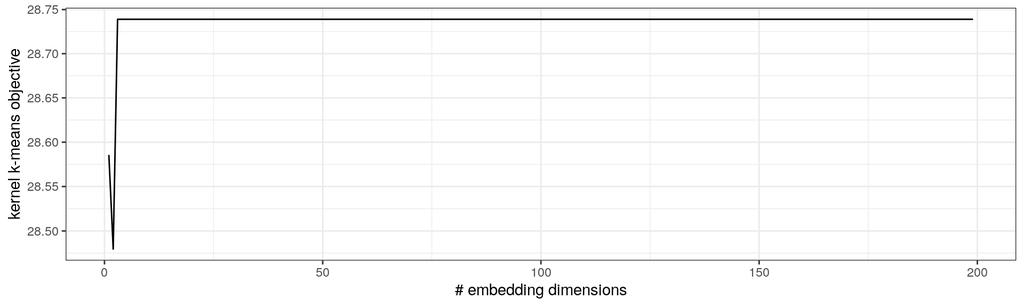

In this case, using a full scaled embedding to match the kernel $k$-means method works, while the typical unscaled $\mathbb{R}^{k-1}$ embedding fails

However, in practice, if we add too many embedding dimensions, Lloyd’s algorithm is more likely to get stuck in local optima

In the text, there is an example where both approaches fail

# Example: Triple Spiral

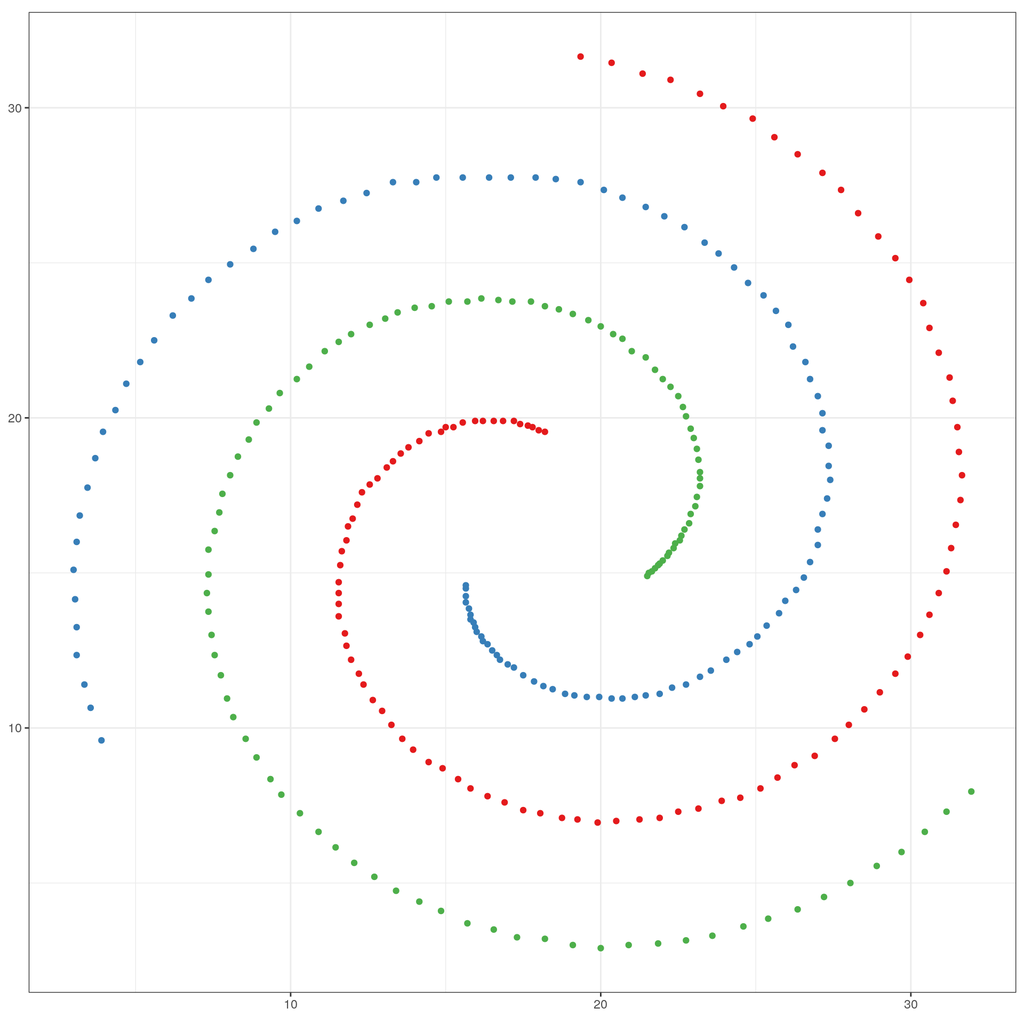

Again, we are less interested in this configuration of points and more interested in a graph generated by these points.

# Example: Triple Spiral

5 nearest neighbors graph

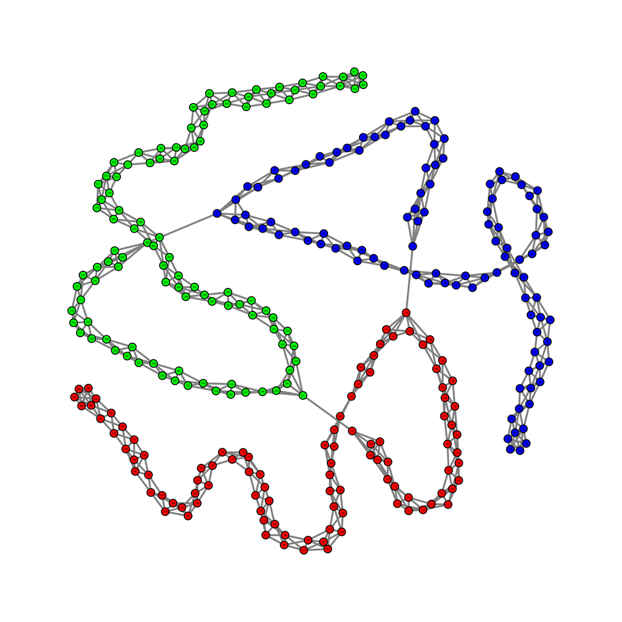

RCut using *a priori* labels: 0.058

# Example: Triple Spiral

Typical spectral clustering method: Embed in $\mathbb{R}^{k-1}$, then perform $k$-means clustering on the embedding:

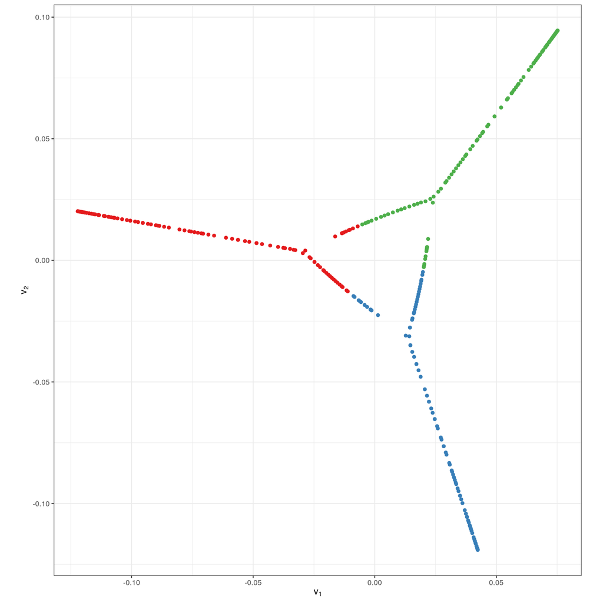

RCut using typical spectral clustering method: 0.25

# Example: Triple Spiral

What if we embed in more dimensions?

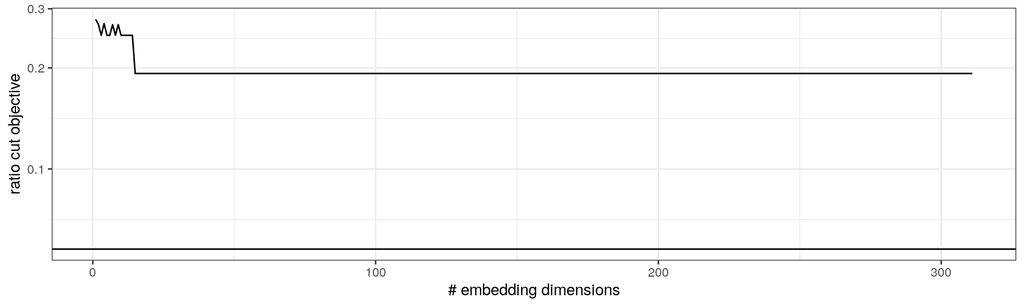

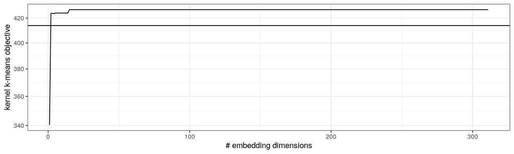

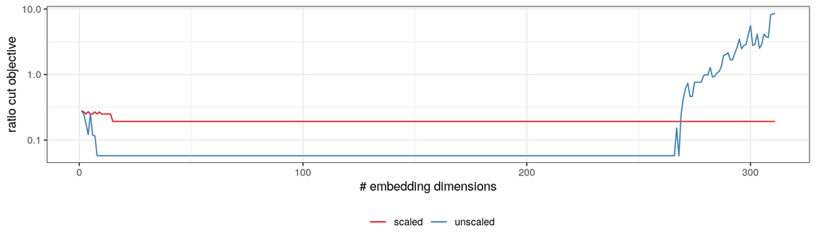

Surprising result: The scaled embedding never found the optimal ratio cut clustering while the unscaled embedding did (until $d > 268$)

# Alternative Approaches

Alternative kernel $k$-means formulation[^1]:

$$\arg\max_H \bigg\{ \text{Tr}(N^{-1/2} H^\top (cI - L) H N^{-1/2}) \bigg\}$$

- $I$ is the $n \times n$ identity matrix
- $c \in \mathbb{R}$ is some parameter

# Alternative Approaches

Kernel $k$-means criterion with kernel matrix $cI - L$:

$$\arg\max_H \bigg\{ \text{Tr}(N^{-1/2} H^\top (cI - L) H N^{-1/2}) \bigg\}$$

$\text{Tr}(N^{-1/2} H^\top (cI - L) H N^{-1/2})$  
$= \text{Tr}(N^{-1/2} H^\top (cI) H N^{-1/2} - N^{-1/2} H^\top L H N^{-1/2})$  
$= \text{Tr}(N^{-1/2} H^\top (cI) H N^{-1/2}) - \text{Tr}(N^{-1/2} H^\top L H N^{-1/2})$  
$= c \text{Tr}(N^{-1/2} H^\top H N^{-1/2}) - \text{Tr}(N^{-1/2} H^\top L H N^{-1/2})$  
$= c \text{Tr}(I_k) - \text{Tr}(N^{-1/2} H^\top L H N^{-1/2})$  
$= ck - \text{Tr}(N^{-1/2} H^\top L H N^{-1/2})$

So this is equivalent to:

$$\arg\min_H \bigg\{ \text{Tr}(N^{-1/2} H^\top L H N^{-1/2}) \bigg\}$$

# Alternative Approaches

Let $v$ be an eigenvector of $L$ with corresponding eigenvalue $\lambda$

$(cI - L) v$  
$= cIv - Lv$  
$= cv - \lambda v$  
$= (c - \lambda) v$

$\implies$ $v$ is an eigenvector of $cI - L$ with corresponding eigenvalue $c - \lambda$

If we choose $c$ to be at least as big as the largest eigenvalue of $L$, then $cI - L$ is positive semidefinite or positive definite.

Then we can perfectly embed $cI - L$ using PCA.

# Alternative Approaches

Given a fully connected, undirected graph $\mathcal{G} = (V, E)$ with similarity matrix $W$ …

1. Compute the graph Laplacian matrix $L = T - W$
2. Set $c \geq \lambda_{n-1}$, the largest eigenvalue of $L$
3. Compute $B = cI - L$
4. Fully embed $B$ using PCA
5. Perform $k$-means clustering on the embedding (e.g., using Lloyd’s algorithm)

This embedding is almost the same as our Laplacian eigenmap of $L$ or PCA embedding of $L^\dagger$, just with different scaling.

If you can perform each of these steps, you will solve the ratio cut problem.

In practice, this doesn’t work so well.

- Easily stuck in local minima in step 5

# Alternative Approaches

Semipositive programming[^2]:

- Instead of relaxing the constraint on $U = H N^{-1/2}$ to allow $U$ to be any real-valued matrix, force $U \in \mathbb{R}^{n \times k}$ to have nonnegative entries
- Use Lloyd’s algorithm (or other $k$-means solvers) on the columns of relaxed and nonnegative $U$ per usual
- If we can solve the $k$-means problem on this version of $U$, under certain constraints, we are guaranteed to obtain the ratio cut partitioning
- Not clear how to actually obtain this nonnegative relaxed $U$ efficiently (open problem)

# Open Problems

1. When is $\arg\min_U \text{Tr}(U^\top L U) = \arg\max_U \text{Tr}(U^\top L^\dagger U)$?
2. Are there other approaches to solving ratio cut?
   - Exchange algorithms
   - Stochastic gradient descent
   - $k$-medioids
3. Alternative kernel $k$-means formulations
[^1]: [Dhillon, Guan, Kulis](https://pdfs.semanticscholar.org/0f28/993f09606a3e3f6c5c9b6d17138f27d85069.pdf)
[^2]: [Ling, Strohmer](https://arxiv.org/pdf/1806.11429.pdf)